# Base population and traits

Marcio Resende, professor[^1]

Marco Antonio Peixoto, Post doc[^2]

## Introduction

As we recall from the first part, in a way to implement a set of simulations in the `AlphaSimR` four steps must be followed:

1. Simulate founder genomes/haplotypes.
2. Set global simulation parameters for a target trait/traits.
3. Model the breeding program.
4. Examine results by looking into population individuals’ metrics.

In this vignette, we will cover a few useful functions from **AlphaSimR** that will help to Model the breeding program.

We will start by loading the packages.

```r
# Loading packages
library(AlphaSimR)
```

```r
library(ggplot2)
```

## Implementing a breeding program in AlphaSimR

### Base Genome

Let’s start the simulation by creating the base genome.

```r
# Base Genome
founderGenomes = runMacs(nInd = 100,
                         nChr = 10,
                         segSites = 100,
                         species = "MAIZE")


# Setting up trait characteristics
SP = SimParam$new(founderGenomes)
SP$addTraitA(nQtlPerChr = 100,
             mean = 10,
             var = 1)

# Generating base population
Parents = newPop(founderGenomes)
```

### Making crosses

First, at the begin of each breeding cycle, we generate new crosses.

```r
# Crossing randomly
F1pop = randCross(pop = Parents, nCrosses = 100)

# Make crosses by a list of individuals
# Making the crossing plan
MatingPlan = data.frame(Parent1 = Parents@id[1:5],
                        Parent2 = Parents@id[6:10])
# Crossing based on the crossing list
F1Pop = makeCross(Parents, crossPlan = as.matrix(MatingPlan))

# Checking out the pedigree records from these F1
Pedigree = data.frame(Ind = F1Pop@id,
                 Parent1 = F1Pop@mother,
                 Parent2 = F1Pop@father)
```

### Advance the genotypes

Now, we can advance the materials

```r
  # Advancing F1->F2
  F2pop = self(pop = F1pop, nProgeny = 10)
```

Then, we may assume phenotypes for all those individuals. The phenotypes assumed came from the genetic values generated before for the individuals. Then, **AlphaSimR** add in each genetic value a random error sampled from a multivariate normal distribution in the function `setPheno()`. Some important arguments in the function `setPheno()` are:

**pop** = the target population to assumed the phenotypes. **h2** = narrow-sense heritability. **H2** = broad-sense heritability. **varE** = residual variance. **reps** = number of repetitions. **p** = the p-value for the environmental covariate used by GxE traits. If NULL, a value is sampled at random.

There are three options for assuming the error variance before mentioned. We can set the argument *h2*, *H2*, *varE*. The user should use only one of these arguments. If the user supplies values for more than one, only one will be used according to the order in which they are listed above.

```r
# Setting phenotypes
F2popvarE = setPheno(pop = F2pop, varE = 10, reps = 1) # Option 1

F2poph2 = setPheno(pop = F2pop, h2 = 0.5, reps = 1) # Option 2

F2popH2 = setPheno(pop = F2pop, H2 = 0.6, reps = 1) # Option 3


# Correlation

df = data.frame('VarE' = cor(F2popvarE@gv, F2popvarE@pheno),
                'h2' = cor(F2poph2@gv, F2poph2@pheno),
                'H2' = cor(F2popH2@gv, F2popH2@pheno))
df
```

```
##          Trait1 Trait1.1  Trait1.2
## Trait1 0.341448 0.781729 0.8274335
```

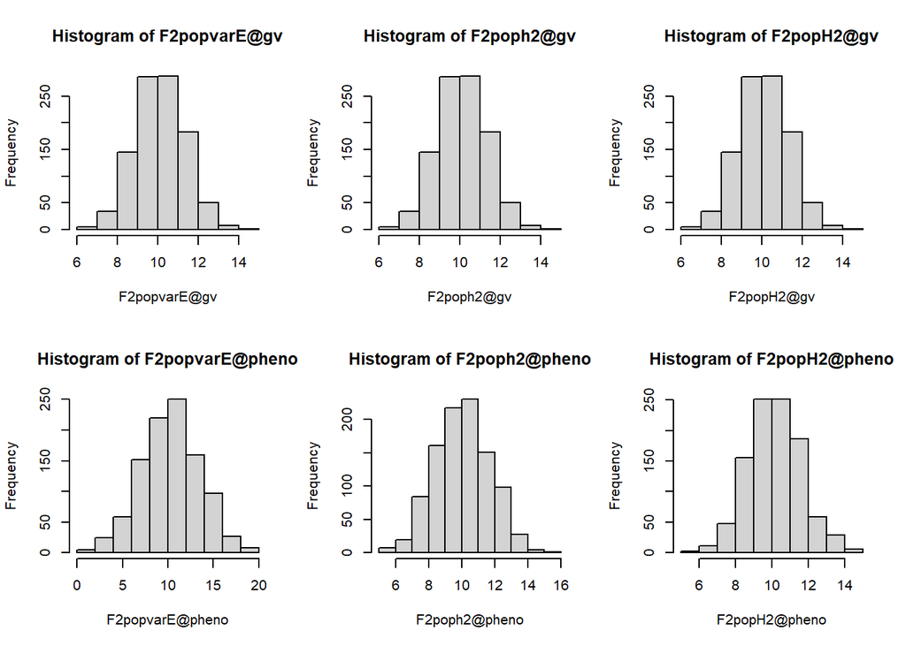

```r
# Plotting the values
par(mfrow = c(2,3))

hist(F2popvarE@gv)
hist(F2poph2@gv)
hist(F2popH2@gv)
hist(F2popvarE@pheno)
hist(F2poph2@pheno)
hist(F2popH2@pheno)
```

The *reps* argument is for convenient representation of replicated data. It is intended to represent replicated yield trials in plant breeding programs. In this case, varE is set to the plot error and reps is set to the number of plots per entry. The resulting phenotype represents the entry-means.

We will explore more in the following populations:

```r
# Setting phenotypes
F2pheno1 = setPheno(F2pop, varE = 10, reps = 1) # Option 1


# Setting phenotypes
F2pheno6 = setPheno(F2pop, varE = 10, reps = 6) # Option 1


# Setting phenotypes
F2pheno10 = setPheno(F2pop, varE = 10, reps = 10) # Option 1


cor(F2pheno1@gv, F2pheno1@pheno)
```

```
##           Trait1
## Trait1 0.3770318
```

```r
cor(F2pheno6@gv, F2pheno6@pheno)
```

```
##           Trait1
## Trait1 0.7094868
```

```r
cor(F2pheno10@gv, F2pheno10@pheno)
```

```
##           Trait1
## Trait1 0.7704048
```

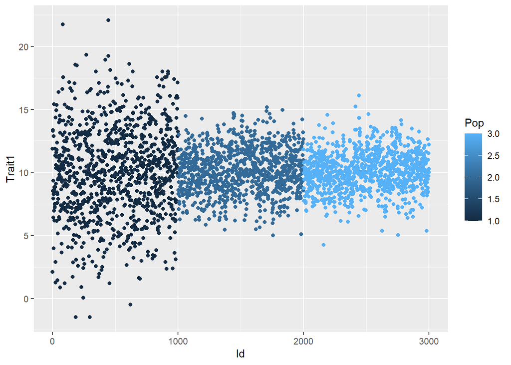

```r
# Plotting the parameters
df = data.frame(Trait1 = c(F2pheno1@pheno,F2pheno6@pheno,F2pheno10@pheno),
                Id = c(1:(3*nInd(F2pop))),
                Pop = rep(c(1,2,3), each=nInd(F2pop)))

#require(ggplot2)
ggplot(df, aes(x = Id, y = Trait1, color = Pop)) +
  geom_point()
```

We will explore more in the following populations:

```r
# Setting phenotypes
F2_pop1 = setPheno(F2pop, reps = 2, h2 = 0.1, p = 0.9) # Option 1


# Setting phenotypes
F2_pop2 = setPheno(F2pop, reps = 2, h2 = 0.1, p = 0.5) # Option 1


# Setting phenotypes
F2_pop3 = setPheno(F2pop, reps = 2, h2 = 0.1, p = 0.1) # Option 1


cor(F2_pop1@gv, F2_pop1@pheno)
```

```
##           Trait1
## Trait1 0.4988398
```

```r
cor(F2_pop2@gv, F2_pop2@pheno)
```

```
##           Trait1
## Trait1 0.4989614
```

```r
cor(F2_pop3@gv, F2_pop3@pheno)
```

```
##           Trait1
## Trait1 0.5091293
```

Now, we can do selections:

```r
# Advancing F1->F2
F2pop = self(pop = F1pop, nProgeny = 1)

# Setting phenotypes
F2pop = setPheno(F2pop, varE = 10, reps = 1)

# Select the best performing individuals according to their phenotype
F2popSel = selectInd(pop = F2pop,
                            nInd = 20,
                            use = "pheno") # gv, pheno, bv, ebv

# Create a new population and phenotype it
newPop = randCross(F2popSel, nCrosses = 100)
newPop = setPheno(newPop, h2 = 0.5)

# Evaluate observed response to selection between generations
# (as the difference between the mean of genetic values)
(deltaGObserved_h205 = mean(gv(newPop)) - mean(gv(F2pop)))
```

```
## [1] 0.7065213
```

## Plotting

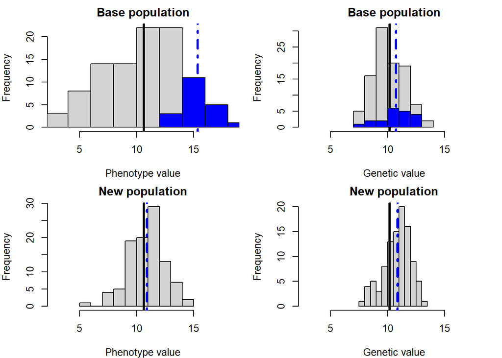

```r
phenoRange = range(pheno(c(F2pop, newPop)))
par(mfrow = c(2, 2),
    mar = c(4, 4, 2, 1))
# Phenotype values in the base population and the selected individuals
tmp = hist(pheno(F2pop), xlim = phenoRange, xlab = "Phenotype value", main = "Base population")
abline(v = mean(pheno(F2pop)), col = "black", lty = 1, lwd = 3)
hist(pheno(F2popSel), col = "blue", breaks = tmp$breaks, add = TRUE)
abline(v = mean(pheno(F2popSel)), col = "blue", lty = 4, lwd = 3)

# Genetic values in the base population and the selected individuals
tmp = hist(gv(F2pop), xlim = phenoRange, xlab = "Genetic value", main = "Base population")
abline(v = mean(gv(F2pop)), col = "black", lty = 1, lwd = 3)
hist(gv(F2popSel), col = "blue", breaks = tmp$breaks, add = TRUE)
abline(v = mean(gv(F2popSel)), col = "blue", lty = 4, lwd = 3)

# Phenotype values in the new population
hist(pheno(newPop), xlim = phenoRange, xlab = "Phenotype value", main = "New population")
abline(v = mean(pheno(F2pop)), col = "black", lty = 1, lwd = 3)
abline(v = mean(pheno(newPop)), col = "blue", lty = 4, lwd = 3)

# Genetic values in the new population
hist(gv(newPop), xlim = phenoRange, xlab = "Genetic value", main = "New population")
abline(v = mean(gv(F2pop)), col = "black", lty = 1, lwd = 3)
abline(v = mean(gv(newPop)), col = "blue", lty = 4, lwd = 3)
```

Do it to the end of the pipeline

```r
  # Advancing F2->F3 and selection
  F3pop = self(pop = F2pop, nProgeny = 4)
  F3pop = setPheno(F3pop, varE = 10, reps = 3)

  F3popSel = selectWithinFam(F3pop, nInd = 4, use = "pheno")
  F3popSel = selectInd(F3popSel, nInd = 300, use = "pheno")

   # Advancing F3->F4 and selection
  F4pop = self(pop = F3popSel, nProgeny = 2)
  F4pop = setPheno(F4pop, varE = 10, reps = 5)

  F4popSel = selectWithinFam(F4pop, nInd = 1, use = "pheno")
  F4popSel = selectInd(F4popSel, nInd = 50, use = "pheno")

  # Advancing F4->F5 and selection
  F5pop = self(pop = F4popSel, nProgeny = 1)
  F5pop = setPheno(F5pop, varE = 10, reps = 8)

  F5popSel = selectInd(F5pop, nInd = 10, use = "pheno")

  # Advancing F5->F6 and selection
  F6pop = self(pop = F5popSel, nProgeny = 1)
  F6pop = setPheno(F6pop, varE = 10, reps = 10)

  F6Sel = selectInd(F6pop, nInd = 5, use = "pheno")

  # Selecting Variety
  F6Sel = setPheno(F6Sel, varE = 10, reps = 20)
  Variety = selectInd(F6Sel, nInd = 1, use = "pheno")
```

# Some (other) useful functions for **AlphaSimR**

```r
# Making DHs
F1 = randCross(Parents,120,1)

# DHs
DHs = makeDH(F1, nDH = 10)

# Hybrid Cross
tester = DHs[1:5]

lines = DHs[6:105]

# Hybrid cross
Hybrids = hybridCross(tester, lines, crossPlan = 'testcross')
length(unique(Hybrids@father))
```

```
## [1] 100
```

```r
# Set pheno for CGA
linesGCA = setPhenoGCA(lines, tester, h2 = 0.2)
lines = setPheno(lines, h2 = 0.2)

cor(linesGCA@pheno, lines@pheno)
```

```
##          Trait1
## [1,] 0.07517686
```

## Evaluating changes overtime

```r
# Set simulation parameters for the scenario with trait heritability of 0.5 and 10 selected
heritability = 0.5
nSelected1 = 100
nSelected2 =25

#


# Phenotype base population
basePop = setPheno(F3popSel, h2 = heritability)

##------------------- For first scenario
# Select the best performing individuals according to their phenotype
basePopSelected = selectInd(pop = basePop,
                            nInd = nSelected1,
                            use = "pheno")

# Allocate vectors
nGenerations = 10 + 1 # +1 to store starting generation
meanGAll = numeric(nGenerations)
varGAll = numeric(nGenerations)

# Save the starting values
meanGAll[1] = meanG(basePop)
varGAll[1] = varG(basePop)

# To make the for loop below simpler we will make a copy of the object basePopSelected
newPopSelected = basePopSelected

# Selection over many generations
for (generation in 1:(nGenerations - 1)) {
  # Cross parents, phenotype progeny, and select new parents
  newPop = randCross(newPopSelected, nCrosses = nInd(basePop))
  newPop = setPheno(newPop, h2 = heritability)
  newPopSelected = selectInd(pop = newPop,
                             nInd = nSelected1,
                             use = "pheno")
  # Save summaries
  meanGAll[1 + generation] = meanG(newPop)
  varGAll[1 + generation] = varG(newPop)
}

# Now save these outputs by copying the objects
meanGAll_n10 = meanGAll
varGAll_n10 = varGAll

##------------------- For second scenario
# Select the best performing individuals according to their phenotype
basePopSelected = selectInd(pop = basePop,
                            nInd = nSelected2,
                            use = "pheno")

# Allocate vectors
nGenerations = 10 + 1 # +1 to store starting generation
meanGAll = numeric(nGenerations)
varGAll = numeric(nGenerations)

# Save the starting values
meanGAll[1] = meanG(basePop)
varGAll[1] = varG(basePop)

# To make the for loop below simpler we will make a copy of the object basePopSelected
newPopSelected = basePopSelected

# Selection over many generations
for (generation in 1:(nGenerations - 1)) {
  # Cross parents, phenotype progeny, and select new parents
  newPop = randCross(newPopSelected, nCrosses = nInd(basePop))
  newPop = setPheno(newPop, h2 = heritability)
  newPopSelected = selectInd(pop = newPop,
                             nInd = nSelected2,
                             use = "pheno")
  # Save summaries
  meanGAll[1 + generation] = meanG(newPop)
  varGAll[1 + generation] = varG(newPop)
}

# Now save these outputs by copying the objects
meanGAll_n50 = meanGAll
varGAll_n50 = varGAll
```

Lets plot and see the changes overtime

[figure not shown]

```r
par(mfrow = c(2, 1),
    mar = c(4, 4, 1, 1))

# Plot mean of genetic values over time
meanRanges = range(c(meanGAll_n10, meanGAll_n50))
plot(x = 1:nGenerations, y = meanGAll_n10, type = "l", col = "black", lwd = 3,
     xlab = "Generation", ylab = "Mean of genetic values", ylim = meanRanges)
lines(x = 1:nGenerations, y = meanGAll_n50, type = "l", col = "purple", lty = 2, lwd = 3)
legend(x = "topleft", legend = c(10, 50), title = "nSelected",
       lwd = 3, lty = c(1, 2), col = c("black", "purple"), bty = "n")

# Plot variance of genetic values over time
varRanges = range(c(varGAll_n50, varGAll_n10))
plot(x = 1:nGenerations, y = varGAll_n10, type = "l", col = "black", lwd = 3,
     xlab = "Generation", ylab = "Variance of genetic values", ylim = varRanges)
lines(x = 1:nGenerations, y = varGAll_n50, type = "l", col = "purple", lty = 2, lwd = 3)
legend(x = "topright", legend = c(10, 50), title = "nSelected",
       lwd = 3, lty = c(1, 2), col = c("black", "purple"), bty = "n")
```

## Multi traits

```r
# Clean the working environment
rm(list = ls())

# Load AlphaSimR, simulate founder genomes, define a trait, and simulate a base population
library(AlphaSimR)
founderGenomes = runMacs(nInd = 100,
                         nChr = 10,
                         segSites = 100,
                         species = "MAIZE")


SP = SimParam$new(founderGenomes)

SP$addTraitA(nQtlPerChr = 100,
             mean = c(10, 2),
             var = c(1,1),
             corA = matrix(data=c(0.5,0.1,0.1,0.5), ncol = 2))

Parents = newPop(founderGenomes)

# Pedigree information
```

```r
# Crossing randomly
F1pop = randCross(pop = Parents, nCrosses = 100)

# Advancing F1->F2
F2pop = self(pop = F1pop, nProgeny = 1)

# Setting phenotypes
F2pop = setPheno(F2pop, varE = c(10, 2), reps = 1)

# Select the top individuals based on their phenotypes - trait 1
popSelT1 = selectInd(pop = F2pop,
                     nInd = 20,
                     use = "pheno",
                     trait = 1) # gv, pheno, bv, ebv

# Select the top individuals based on their phenotypes - trait 2
popSelT2 = selectInd(pop = F2pop,
                     nInd = 20,
                     use = "pheno",
                     trait = 2) # gv, pheno, bv, ebv


# Select the top individuals based on their phenotypes - trait 2
popSelBoth = selectInd(pop = F2pop,
                     nInd = 20,
                     use = "pheno",
                     trait = selIndex,
                     b=c(0.5,0.5)) # index



# Data frame with results
df = data.frame(Basepop = c(apply(F2pop@pheno, 2, FUN = mean)),
                Sel_T1 = c(apply(popSelT1@pheno, 2, FUN = mean)),
                Sel_T2 = c(apply(popSelT2@pheno, 2, FUN = mean)),
                Sel_Both = c(apply(popSelBoth@pheno, 2, FUN = mean)))
df
```

```
##          Basepop    Sel_T1    Sel_T2 Sel_Both
## Trait1 10.521069 14.900460 11.278828 14.40202
## Trait2  1.862643  2.230762  4.272132  3.11193
```

## References

[^1]: University of Florida, mresende@ufl.edu
[^2]: University of Florida, deamorimpeixotom@ufl.edu